# Working with data

# Data Preparation

Before you can visualise your data, you have to get it into R. This involves importing the data from an external source and converting it into a useful format.

## Importing data

R can import data from almost any source, including text files, excel spreadsheets, statistical packages, and database management systems. We’ll illustrate these techniques using the Salaries dataset, containing the 9-month academic salaries of college professors at a single institution in 2008-2009.

# Text files

The readr package provides functions for importing delimited text files into R data frames.

```r
library(readr)
```

# import data from a comma delimited file

```r
Salaries <- read.csv("salaries.csv")
```

# import data from a tab delimited file

```r
Salaries <- read.table("salaries.txt")
```

These functions assume that the first line of data contains the variable names, values and are separated by commas or tabs respectively, and that missing data are represented by blanks.

# Excel spreadsheets

The readxl package can import data from Excel workbooks. Both xls and xlsx formats are supported.

```r
library(readxl)
```

# import data from an Excel workbook

```r
Salaries <- read_excel("salaries.xlsx", sheet=1)
```

Since workbooks can have more than one worksheet, you can specify the one you want with the sheet option. The default is sheet=1.

# Statistical packages

The haven package provides functions for importing data from a variety of statistical packages.

```r
library(haven)
```

## Converting csv to dta

```r
library(haven)
x <- read.csv("salaries.csv")

# Replace illegal characters in variable names
names(x) <- gsub("\\.", "_", names(x))

# Write to Stata format
write_dta(x, "salaries.dta")
```

# import data from Stata

```r
Salaries <- read_dta("salaries.dta")
```

## Converting csv to SPSS

```r
write_sav(Salaries, "salaries.sav")
```

# import data from SPSS

```r
Salaries <- read_sav("salaries.sav")
```

# import data from SAS

```r
Salaries <- read_sas("salaries.sas7dbat")
```

# Selecting variables

The select function allows you to limit your dataset to specified variables (columns).

```r
library(dplyr)
```

# keep the variables name, height and gender

```r
newdata <- select(starwars, name, height, gender)
```

# keep the variables name and all variables between mass and species inclusive

```r
newdata <- select(starwars, name, mass:species)
```

# keep all variables except birth_year and gender

```r
newdata <- select(starwars, -birth_year, -gender)
```

# Selecting observations

```r
library(dplyr)
```

# select females

```r
newdata <- filter(starwars,
                  gender == "feminine")
```

# select females that are from Alderaan

```r
newdata <- filter(starwars,
                  gender == "feminine" &
                    homeworld == "Alderaan")
```

# select individuals that are from Alderaan , Coruscant or Endor

```r
newdata <- filter(starwars,
                    homeworld == "Alderaan" |
                    homeworld == "Coruscant" |
                    homeworld == "Endor")
```

# this can be written more succinctly as

```r
newdata <- filter(starwars,
                    homeworld %in% c("Alderaan", "Coruscant", "Endor"))
```

# Creating/Recoding variables

The mutate function allows you to create new variables or transform existing ones.

```r
library(dplyr)
```

# convert height in centimeters to inches, and mass in kilograms to pounds

```r
newdata <- mutate(starwars,
                  height = height * 0.394,
                  mass = mass * 2.205)
```

The ifelse function (part of base R) can be used for recoding data. The format is ifelse(test, return of TRUE, return if FALSE).

```r
library(dplyr)
```

```r
newdata <- mutate(starwars,
                  heightcat = ifelse(height > 180,
                                     "tall",
                                     "short"))
```

# convert any eye colour that is not black, blue or brown, to other

```r
newdata <- mutate(starwars,
                  eye_color = ifelse(eye_color %in% c("black", "blue", "brown"),
                                     eye_color, "other"))
```

# set heights greater than 200 or less than 75 to missing

```r
newdata <- mutate(starwars, height = ifelse(height < 75 | height > 200,
                                            NA,
                                            height))
```

# Summarizing data

# calculate mean height and mass

```r
newdata <- summarise(starwars,
                     mean_ht = mean(height, na.rm=TRUE),
                     mean_mass = mean(mass, na.rm=TRUE))

newdata
```

| mean_ht | mean_mass |
| --- | --- |
| 174.6049 | 97.31186 |

# calculate mean height and weight by gender

```r
newdata <- group_by(starwars, gender)
starwars <- summarise(newdata,
                      mean_ht = mean(height, na.rm=TRUE),
                      mean_wt = mean(mass, na.rm=TRUE))
```

# Using pipes

Packages like dplyr and tidyr allow you to write your code in a compact format using the pipe %>% operator.

# Calculate mean height for women by species

```r
newdata <- filter(starwars,
                  gender == "feminine")
newdata <- group_by(newdata, species)
newdata <- summarise(newdata,
                     mean_ht = mean(height, na.rm=TRUE))
```

# this can be written as

```r
newdata <- starwars %>%
  filter(gender == "feminine") %>%
  group_by(species) %>%
  summarise(mean_ht = mean(height, na.rm = TRUE))
```

The pipe operator passes the result on the left to the first parameter of the function on the right.

# Reshaping data

Some graphs require the data to be in wide format, while some graphs require the data to be in long format.

# convert a wide dataset to a long dataset

```r
library(tidyr)
#Just an example (not real data)
long_data <- gather(wide_data,
                    key = "variable",
                    value = "value",
                    sex:income)
```

# convert a long dataset into a wide dataset

```r
library(tidyr)
#Just an example (not real data)
wide_data < spread(long_data, variable, value)
```

# Missing data

Real data is likely to contain missing values. There are three basic approaches to dealing with missing data: feature selection, listwise deletion and imputation. Let’s see how each applies to the msleep dataset from the ggplot2 package. The msleep dataset describes the sleep habits of mammals and contains missing values on several variables.

# Feature selection

In feature selection, you delete variables (columns) that contain too many missing values.

```r
data(msleep, package="ggplot2")

# what is the proportion of missing data for each variable?

pctmiss <- colSums(is.na(msleep))/nrow(msleep)
round(pctmiss, 2)
```

```
        name        genus         vore        order conservation  sleep_total    sleep_rem  sleep_cycle        awake      brainwt       bodywt
        0.00         0.00         0.08         0.00         0.35         0.00         0.27         0.61         0.00         0.33         0.00
```

Sixty-one percent of sleep_cycle values are missing. You may decide to drop it.

# Listwise deletion

listwise deletion involves deleting observations (rows) that contain missing values on any of the variables of interest.

# create a dataset containing genus, vore, and conservation. Delete any rows containing missing data

```r
newdata <- select(msleep, genus, vore, conservation)
newdata <- na.omit(newdata)
```

# Imputation

Imputation involves replacing missing values with “reasonable” guesses abut what the values would have been if they had not been missing. There are several approaches, as detailed in packages as VIM, mice, Amelia and missForest. Here we will use the kNN function from the VIM package to replace missing values with imputed values.

# impute missing values with 5 nearest neighbours

```r
library(VIM)
newdata <- kNN(msleep, k=5)
```

Basically, for each case with a missing value, the k most similar cases not having a missing value are selected. If the missing value is numeric, the mean of those k cases is used as the imputed value. If the missing value is categorical, the most frequent value from the k cases is used. The process iterates over cases and variables until the results coverage (become stable). This is a bit of an oversimplification.

Important caveat - Missing values can bias the results of studies (sometimes severely). If you have a significant amount of missing data it is probably a good idea to consult a statistician or data scientist before deleting cases or imputing missing values.

# Lab 1

# import data

```r
edidiv <- read.csv("edidiv.csv")
```

# check data was imported without mistakes

```r
head(edidiv)
```

|  | organisationName | gridReference | year | taxonName | taxonGroup |
| --- | --- | --- | --- | --- | --- |
| 1 | Joint Nature Conservation Committee | NT265775 | 2000 | Sterna hirundo | Bird |
| 2 | Joint Nature Conservation Committee | NT235775 | 2000 | Sterna hirundo | Bird |
| 3 | Joint Nature Conservation Committee | NT235775 | 2000 | Sterna paradisaea | Bird |
| 4 | British Trust for Ornithology | NT27 | 2000 | Branta canadensis | Bird |
| 5 | British Trust for Ornithology | NT27 | 2000 | Branta leucopsis | Bird |
| 6 | The Wildlife Information Centre | NT27S | 2001 | Turdus merula | Bird |

```r
tail(edidiv)
```

|  | organisationName | gridReference | year | taxonName | taxonGroup |
| --- | --- | --- | --- | --- | --- |
| 25679 | The Mammal Society | NT278745 | 2016 | Sciurus carolinensis | Mammal |
| 25680 | The Mammal Society | NT277724 | 2016 | Capreolus capreolus | Mammal |
| 25681 | The Mammal Society | NT266728 | 2016 | Sciurus carolinensis | Mammal |
| 25682 | The Mammal Society | NT270728 | 2016 | Oryctolagus cuniculus | Mammal |
| 25683 | The Mammal Society | NT257762 | 2016 | Vulpes vulpes | Mammal |
| 25684 | People's Trust for Endangered Species | NT2372 | 2016 | Erinaceus europaeus | Mammal |

```r
str(edidiv)
```

```
'data.frame':   25684 obs. of  5 variables:
 $ organisationName: chr  "Joint Nature Conservation Committee" "Joint Nature Conservation Committee" "Joint Nature Conservation Committee" "British Trust for Ornithology" ...
 $ gridReference   : chr  "NT265775" "NT235775" "NT235775" "NT27" ...
 $ year            : int  2000 2000 2000 2000 2000 2001 2001 2001 2001 2001 ...
 $ taxonName       : chr  "Sterna hirundo" "Sterna hirundo" "Sterna paradisaea" "Branta canadensis" ...
 $ taxonGroup      : chr  "Bird" "Bird" "Bird" "Bird" ...
```

# Converting data types

```r
head(edidiv$taxonGroup) # Displays the first few rows of this column only
```

[output not shown]

```r
class(edidiv$taxonGroup) # Tells you what type of variable we're dealing with : it's a character now but we want it to be a factor.
```

[output not shown]

```r
edidiv$taxonGroup <- as.factor(edidiv$taxonGroup) # Changes the variable from it's current type 'character' into a factor and assigning it.

class(edidiv$taxonGroup)
```

```
[1] "factor"
```

# Filtering data

```r
unique(edidiv$taxonGroup)
```

```
 [1] Bird             Flowering.Plants Fungus           Beetle           Butterfly        Dragonfly        Hymenopteran     Lichen           Liverwort
[10] Mollusc          Mammal
Levels: Beetle Bird Butterfly Dragonfly Flowering.Plants Fungus Hymenopteran Lichen Liverwort Mammal Mollusc
```

```r
Beetle <- filter(edidiv, taxonGroup == "Beetle") # Creates a dataframe with only information for beetles.

Bird <- filter(edidiv, taxonGroup == "Bird") # # Creates a dataframe with only information for birds , and so on....

Butterfly <- filter(edidiv, taxonGroup == "Butterfly")

Dragonfly <- filter(edidiv, taxonGroup == "Dragonfly")

Hymenopteran <- filter(edidiv, taxonGroup == "Hymenopteran")

Lichen <- filter(edidiv, taxonGroup == "Lichen")

Liverwort <- filter(edidiv, taxonGroup == "Liverwort")

Mollusc <- filter(edidiv, taxonGroup == "Mollusc")

Mammal <- filter(edidiv, taxonGroup == "Mammal")

Flowering.Plants <- filter(edidiv, taxonGroup == "Flowering.Plants")

Fungus <- filter(edidiv, taxonGroup == "Fungus")
```

# Species richness

```r
a <- length(unique(Beetle$taxonName)) # unique() identifies species and length() counts them
b <- length(unique(Bird$taxonName))
c <- length(unique(Butterfly$taxonName))
d <- length(unique(Dragonfly$taxonName))
e <- length(unique(Hymenopteran$taxonName))
f <- length(unique(Lichen$taxonName))
g <- length(unique(Liverwort$taxonName))
h <- length(unique(Mollusc$taxonName))
i <- length(unique(Mammal$taxonName))
j <- length(unique(Flowering.Plants$taxonName))
k <- length(unique(Fungus$taxonName))
```

# Create a vector

The c() function stands for concatenate (or chain) , names() labels the values

```r
biodiv <- c(a, b, c, d, e, f, g, h, i, j, k)

names(biodiv) <- c("Beetle",
                   "Bird",
                   "Butterfly",
                   "Dragonfly",
                   "Hymenopteran",
                   "Lichen",
                   "Liverwort",
                   "Mollusc",
                   "Mammal",
                   "Flowering.Plants",
                   "Fungus")
```

# Plotting

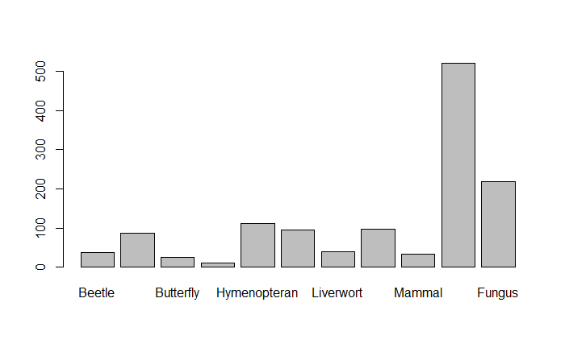

```r
barplot(biodiv)
```

```r
help(barplot) # For help with barplot() function
help(par) # For help with plotting in general
```

# Saving the data to file

```r
# Creating an object called taxa that contains all of the taxa names

taxa <- c("Beetle",
          "Bird",
          "Butterfly",
          "Dragonfly",
          "Hymenopteran",
          "Lichen",
          "Liverwort",
          "Mollusc",
          "Mammal",
          "Flowering.Plants",
          "Fungus")

# Turning this object into a factor (categorical variable)

taxa_f <- factor(taxa)

# Combining all of the values for the number of species in an object called richness

richness <- c(a, b, c, d, e, f, g, h, i, j, k)

# Creating a dataframe from the two vectors

biodata <- data.frame(taxa_f, richness)

# Saving the file

write.csv(biodata, file = "biodata.csv")
```

# Barplot from the dataframe

```r
png("barplot2.png", width = 1600, height = 600)
barplot(biodata$richness, names.arg = c("Beetle",
          "Bird",
          "Butterfly",
          "Dragonfly",
          "Hymenopteran",
          "Lichen",
          "Liverwort",
          "Mollusc",
          "Mammal",
          "Flowering.Plants",
          "Fungus"),
        xlab = "Taxa", ylab = "Number of species", ylim = c(0, 600))
dev.off()
```

# Lab 2

```r
#Calculate the wingspan for every bird type

sparrow <- mean(22, 24, 21)
kingfisher <- mean(26, 23, 25)
eagle <- mean(195, 201, 185)
hummingbird <- mean(8, 9, 9)

# Chain them together in a vector

wingspan <- c(sparrow, kingfisher, eagle, hummingbird)

# Create a bird species vector (matching the order of the previous vector)

bird_sp <- c("sparrow", "kingfisher", "eagle", "hummingbird")

# Change bird_sp into a factor

class(bird_sp)
```

```
[1] "character"
```

```r
bird_sp <- as.factor(bird_sp)
class(bird_sp)
```

```
[1] "factor"
```

```r
# Combine the two vectos into a dataframe

wings <- data.frame(bird_sp, wingspan)
```

# Plot the bar plot and save it to a file

```r
png("wingspan_plot.png", width = 800, height = 600)
barplot(wings$wingspan, names.arg = wings$bird_sp, # Much simpler to call the bird_sp column than typing them all out
        xlab = "Bird Species",
        ylab = "Average Wingspan (cm)", # setting the axis names
        ylim = c(0,200), # setting the limits to fit the eagle
        col = "gold") # colour = gold

dev.off()
```